# Autogenous - LDna chromosome 1

Luciano V Cosme

2026-04-06

> **Population label key:** The code labels used in the analysis below correspond to the following manuscript labels: AUT = AUTO, MAN = NON-AUTO, NEW = NON-AUTO-FIELD.

```r
# Load tidyverse FIRST to avoid rlang version conflict
library(tidyverse)
library(here)
library(scales)
library(ggrepel)

# Then add LDna v.2.15 library path and load
.libPaths(c("/workspace/lib/ldna_v215", .libPaths()))
library(LDna)
library(reshape2)
library(writexl)
```

## 3. LDna chromosome 1

Clean env and memory

```r
# Remove all objects from the environment
rm(list = ls())

# Run the garbage collector to free up memory
gc()
```

```
##           used (Mb) gc trigger  (Mb) max used  (Mb)
## Ncells 1176214 62.9    2281637 121.9  2184539 116.7
## Vcells 1967995 15.1    8388608  64.0  3349542  25.6
```

### 3.1 NEW

Clean env and memory

```r
# Remove all objects from the environment
rm(list = ls())

# Run the garbage collector to free up memory
gc()
```

```
##           used (Mb) gc trigger  (Mb) max used  (Mb)
## Ncells 1176302 62.9    2281637 121.9  2184539 116.7
## Vcells 1968456 15.1    8388608  64.0  3349542  25.6
```

Import the data

```r
ld1 <-
  read.delim(
    here("output", "ldna", "pop", "chr1", "NEW.chr1.txt"),
    sep = "\t",
    header = T,
    row.names = 1,
    stringsAsFactors = F,
    check.names = FALSE
  )
```

Check the LD matrix we built using bash

```r
head(ld1)
```

[output not shown]

[output cut: 10284 more lines]

[output not shown]

The row and column names are correct. Now we can convert the data frame to matrix

```r
# Create the matrix for ldna
ld2<- as.matrix(sapply(ld1, as.numeric))

# Get names
names<- rownames(ld1)
#names<-gsub("-", ".", names)

# Add names
row.names(ld2)<-names

# Clean non-numeric values
ld2[is.nan(ld2)] <- NA
ld2[is.infinite(ld2)] <- NA

# Remove diagonal values = 1
diag(ld2)=NA

# Make sure it is only the lower triangle matrix
ld2[!lower.tri(ld2)] <- NA
```

Create a LDna object

```r
# create the LDna object (change the number of cores as needed)
diag(ld2) <- NA
ld2[!lower.tri(ld2)] <- NA
ldna <- LDnaRaw(ld2, mc.cores=2, method = "single")
```

Save ldna

```r
saveRDS(ldna, file = here("output", "ldna", "pop", "chr1", "NEW.rds"))
saveRDS(ld2, file = here("output", "ldna", "pop", "chr1", "NEW_ld2.rds"))
```

Read the data

```r
ldna <- readRDS(file = here("output", "ldna", "pop", "chr1", "NEW.rds"))
ld2 <- readRDS(file = here("output", "ldna", "pop", "chr1", "NEW_ld2.rds"))
```

Check the object

```r
str(ldna)
```

```
## List of 3
##  $ clusterfile: logi [1:7385, 1:2646] TRUE TRUE TRUE TRUE TRUE TRUE ...
##   ..- attr(*, "dimnames")=List of 2
##   .. ..$ : chr [1:7385] "AX-583033342" "AX-583035163" "AX-583035194" "AX-583035257" ...
##   .. ..$ : chr [1:2646] "2646_0.37" "2645_0.38" "2644_0.4" "2643_0.42" ...
##  $ stats      :Classes 'data.table' and 'data.frame':    10031 obs. of  8 variables:
##   ..$ cluster       : chr [1:10031] "2646_0.37" "2645_0.38" "2644_0.4" "2643_0.42" ...
##   ..$ parent_cluster: chr [1:10031] "root" "2646_0.37" "2645_0.38" "2644_0.4" ...
##   ..$ distance      : chr [1:10031] "0.37" "0.01" "0.02" "0.02" ...
##   ..$ nV            : num [1:10031] 7385 7384 7383 7382 7378 ...
##   ..$ nE            : num [1:10031] 1035242 949416 812163 631353 590984 ...
##   ..$ min_LD        : num [1:10031] 0 0 0 0 0 0 0 0 0 0 ...
##   ..$ merge_at_below: num [1:10031] 0 0.37 0.38 0.4 0.42 0.43 0.44 0.45 0.46 0.47 ...
##   ..$ merge_at_above: num [1:10031] NA 0.38 0.4 0.42 0.43 0.44 0.45 0.46 0.47 0.48 ...
##   ..- attr(*, ".internal.selfref")=<externalptr>
##   ..- attr(*, "index")= int(0)
##   .. ..- attr(*, "__nE")= int [1:10031] 1376 1521 1984 1996 2007 2012 2045 2056 2069 2101 ...
##   .. ..- attr(*, "__parent_cluster")= int [1:10031] 6491 6492 5324 5325 5913 5914 3118 3119 6985 6986 ...
##   .. ..- attr(*, "__cluster")= int [1:10031] 2090 1908 2010 1619 2167 1905 1278 1206 1980 1621 ...
##  $ tree       :List of 4
##   ..$ edge       : int [1:10030, 1:2] 7386 7386 7387 7387 7388 7388 7389 7389 7389 7389 ...
##   ..$ edge.length: num [1:10030] 0.315 0.005 0.31 0.01 0.3 0.01 0.29 0.29 0.29 0.29 ...
##   ..$ tip.label  : chr [1:7385] "AX-583033342" "AX-583035163" "AX-583035194" "AX-583035257" ...
##   ..$ Nnode      : int 2646
##   ..- attr(*, "class")= chr "phylo"
##   ..- attr(*, "order")= chr "cladewise"
```

```r
str(ld2)
```

```
##  num [1:7385, 1:7385] NA 0.00552 0.00107 0.08495 0.0082 ...
##  - attr(*, "dimnames")=List of 2
##   ..$ : chr [1:7385] "AX-583033342" "AX-583035163" "AX-583035194" "AX-583035257" ...
##   ..$ : chr [1:7385] "AX-583033342" "AX-583035163" "AX-583035194" "AX-583035257" ...
```

Extract clusters using min.edges=100

```r
pdf(file = here("output", "ldna", "pop", "chr1", "NEW_extractBranches.pdf"), width = 20, height = 12)
op <- par(mfcol=c(1,4))

clusters <- extractBranches(ldna, min.edges=100, plot.tree=TRUE, cores=1)
summary <- summaryLDna(ldna, clusters, ld2)
write.table(summary, file = here("output", "ldna", "pop", "chr1", "summary_NEW.txt"), row.names=FALSE, sep="\t", quote=FALSE)

par(op)
while (!is.null(dev.list())) dev.off()
```

Get cluster information

```r
# to get the list of names of the clusters
# Find the length of the longest vector
max_length <- max(sapply(clusters, length))

# Function to pad vectors with NAs to make them the same length
pad_vector_to_max_length <- function(vec, max_length) {
  c(vec, rep(NA, max_length - length(vec)))
}

# Apply the padding function to each vector in the list and combine into a data frame
do1 <- as.data.frame(do.call(cbind, lapply(clusters, pad_vector_to_max_length, max_length)))

# to get list of snps for each cluster
do <- do.call(cbind, unname(lapply(clusters, `length<-`, max(lengths(clusters)))))
colnames(do) <- colnames(do1)
```

Create an objet with the clusters and the SNPs in each cluster

```r
max_length <- max(sapply(clusters, length))
# Initialize an empty list
cluster_df_list <- list()

# Loop through each cluster and pad with NAs
for (cluster_name in names(clusters)) {
  cluster_length <- length(clusters[[cluster_name]])
  padded_cluster <- c(clusters[[cluster_name]], rep(NA, max_length - cluster_length))
  cluster_df_list[[cluster_name]] <- padded_cluster
}

# Combine the lists into a data frame
df <- data.frame(cluster_df_list)
# Remove 'X' from column names
names(df) <- make.names(names(df), unique = FALSE)
names(df) <- sub("X", "", names(df), fixed = TRUE)

# Save it
saveRDS(df, file = here("output", "ldna", "pop", "chr1", "NEW_clusters_snps.rds"))
head(df)
```

```
##      2480_0.72    2257_0.78    1581_0.87    1917_0.84    2100_0.81    2099_0.81
## 1 AX-583356612 AX-583290284 AX-583080308 AX-583098517 AX-583083226 AX-583080824
## 2 AX-583365284 AX-583294559 AX-583086832 AX-583119290 AX-583102108 AX-583082994
## 3 AX-583367650 AX-583296765 AX-583130724 AX-583117244 AX-583105324 AX-583080994
## 4 AX-583367931 AX-583299003 AX-583143774 AX-583118579 AX-583126857 AX-583081023
## 5 AX-583370245 AX-583299024 AX-583145470 AX-583129900 AX-583174701 AX-583083122
## 6 AX-583370971 AX-583299574 AX-583185336 AX-583187375 AX-583208045 AX-583085780
##      1915_0.84    2098_0.81
## 1 AX-583080669 AX-583039062
## 2 AX-583089803 AX-583041570
## 3 AX-583101707 AX-583047632
## 4 AX-583109443 AX-583046028
## 5 AX-583109053 AX-583046046
## 6 AX-583112578 AX-583047909
```

We can save it in a different format as well

```r
# Assuming your data frame is named df
long_df <- gather(df, Cluster, SNP, everything())

# View the first few rows of the transformed data
head(long_df)
```

```
##     Cluster          SNP
## 1 2480_0.72 AX-583356612
## 2 2480_0.72 AX-583365284
## 3 2480_0.72 AX-583367650
## 4 2480_0.72 AX-583367931
## 5 2480_0.72 AX-583370245
## 6 2480_0.72 AX-583370971
```

```r
# Save it
saveRDS(long_df, file = here("output", "ldna", "pop", "chr1", "NEW_clusters_snps1.rds"))
```

Make long format

```r
new_chr1 <- melt(do, na.rm = T, value.name = "value")
head(new_chr1)
```

```
##   Var1      Var2        value
## 1    1 2480_0.72 AX-583356612
## 2    2 2480_0.72 AX-583365284
## 3    3 2480_0.72 AX-583367650
## 4    4 2480_0.72 AX-583367931
## 5    5 2480_0.72 AX-583370245
## 6    6 2480_0.72 AX-583370971
```

Update names

```r
colnames(new_chr1)<- c("v1", "cluster", "SNP")
head(new_chr1)
```

```
##   v1   cluster          SNP
## 1  1 2480_0.72 AX-583356612
## 2  2 2480_0.72 AX-583365284
## 3  3 2480_0.72 AX-583367650
## 4  4 2480_0.72 AX-583367931
## 5  5 2480_0.72 AX-583370245
## 6  6 2480_0.72 AX-583370971
```

Import the bim file to get the SNP positions

```r
# Import the function
source(
  here(
    "notebooks", "helpers", "import_bim.R")
)

# Import the data
new_snps_chr1 <- import_bim(here("output", "ldna", "pop", "NEW.bim")) |>
  dplyr::select(
    SNP, Scaffold, Position
  ) |>
  dplyr::rename(
    Chromosome = Scaffold
  )

# Check it
head(new_snps_chr1)
```

```
## # A tibble: 6 x 3
##   SNP          Chromosome Position
##   <chr>        <chr>         <dbl>
## 1 AX-583033342 1            315059
## 2 AX-583035163 1            315386
## 3 AX-583035194 1            330265
## 4 AX-583035257 1            442875
## 5 AX-583035355 1            540754
## 6 AX-583034838 1           1138155
```

Merge the cluster data and the SNP data

```r
# merge dataframes
merged<- merge(new_chr1, new_snps_chr1, by="SNP", all.x=TRUE)
merged<-na.omit(merged)
head(merged)
```

```
##            SNP v1   cluster Chromosome Position
## 1 AX-583039062  1 2098_0.81          1  1671072
## 2 AX-583041570  2 2098_0.81          1  1741057
## 3 AX-583046028  4 2098_0.81          1  2792914
## 4 AX-583046046  5 2098_0.81          1  2793124
## 5 AX-583047632  3 2098_0.81          1  2776876
## 6 AX-583047909  6 2098_0.81          1  2814745
```

Select the columns we need

```r
# subset
merged <- subset(merged, select = c(cluster, SNP, Position))
head(merged)
```

```
##     cluster          SNP Position
## 1 2098_0.81 AX-583039062  1671072
## 2 2098_0.81 AX-583041570  1741057
## 3 2098_0.81 AX-583046028  2792914
## 4 2098_0.81 AX-583046046  2793124
## 5 2098_0.81 AX-583047632  2776876
## 6 2098_0.81 AX-583047909  2814745
```

Sort by distance

```r
merged<- merged[order(merged$Position),,drop=FALSE]
head(merged)
```

```
##     cluster          SNP Position
## 1 2098_0.81 AX-583039062  1671072
## 2 2098_0.81 AX-583041570  1741057
## 5 2098_0.81 AX-583047632  2776876
## 3 2098_0.81 AX-583046028  2792914
## 4 2098_0.81 AX-583046046  2793124
## 6 2098_0.81 AX-583047909  2814745
```

```r
# for parsing later
sushi1<- subset(merged, select = c(cluster, Position))
head(sushi1)
```

```
##     cluster Position
## 1 2098_0.81  1671072
## 2 2098_0.81  1741057
## 5 2098_0.81  2776876
## 3 2098_0.81  2792914
## 4 2098_0.81  2793124
## 6 2098_0.81  2814745
```

Save the data

```r
# Create directory
new_directory_path <- here("output", "ldna", "pop", "chr1", "clusters")
dir.create(new_directory_path, recursive = TRUE)

# save file
write.table(merged, file = here("output", "ldna", "pop", "chr1", "SNPs_clusters_NEW_chr1.txt"), row.names = F, sep = "\t", quote = F)
write.table(sushi1, file = here("output", "ldna", "pop", "chr1", "clusters", "sushi_NEW_chr1.txt"), row.names = F, sep = "\t", quote = F)
```

Parse the file1 to get the start and end of the clusters as well as their size. Remember, recombination make it a mosaic, so the clusters are “mixed”.

```bash
awk '
function print_row() {
    if ( feature != "" )
       print feature, start, end, (end - start)
}

BEGIN {
    FS=OFS="\t";
    print "Cluster", "Start", "End", "Size";
}
NR == 1 { next } # Skip the first line
$1 != feature {
    print_row();
    feature = $1;
    start = $2;
    end = $2;
    next;
}
{
    end = $2;
}
END {
    print_row();
}
' output/ldna/pop/chr1/clusters/sushi_NEW_chr1.txt > output/ldna/pop/chr1/clusters/sushi2_NEW_chr1.txt;
head output/ldna/pop/chr1/clusters/sushi2_NEW_chr1.txt
```

```
## Cluster  Start   End Size
## 2098_0.81    1671072 16303506    14632434
## 1915_0.84    16307511    16307511    0
## 2098_0.81    16308219    16458676    150457
## 1581_0.87    16462946    16462946    0
## 2098_0.81    16479266    16499343    20077
## 2099_0.81    16520133    16535750    15617
## 2098_0.81    16560013    16688706    128693
## 2100_0.81    16712729    16712729    0
## 2098_0.81    16723593    17338376    614783
```

Count how many segments

```r
# Define the path
input_path <- here("output", "ldna", "pop", "chr1", "clusters", "sushi2_NEW_chr1.txt")

# Read the data into R
clusters_data <- read_table(input_path, col_names = TRUE, col_types = NULL)
# Arrange by position
clusters_data <- clusters_data |>
  arrange(Start)

# Count segments for each cluster - if you want only the counts
segment_counts <- clusters_data %>%
  group_by(Cluster) %>%
  summarize(nSegments = n(), .groups = 'drop')

# View the result
head(segment_counts)
```

```
## # A tibble: 6 x 2
##   Cluster   nSegments
##   <chr>         <int>
## 1 1581_0.87        42
## 2 1915_0.84        52
## 3 1917_0.84        38
## 4 2098_0.81       225
## 5 2099_0.81        29
## 6 2100_0.81        50
```

Plot it

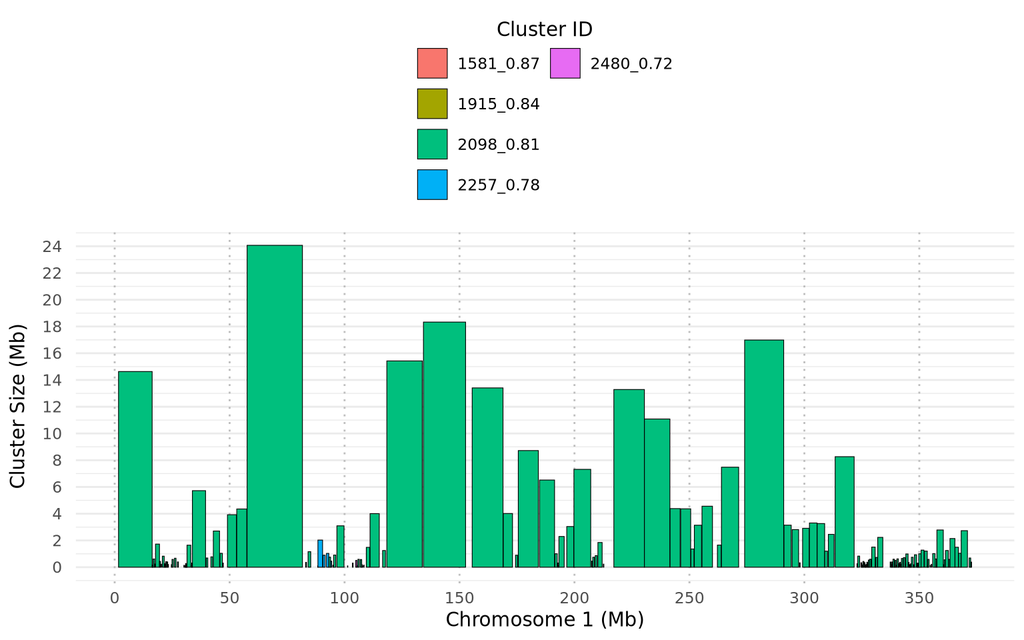

```r
# Define the path
input_path <-
  here("output",
       "ldna",
       "pop",
       "chr1",
       "clusters",
       "sushi2_NEW_chr1.txt")

# Read the data into R
clusters_data <- read.table(input_path, header = TRUE, sep = "\t") |>
  arrange(Start)

# Filter out rows with Size equal to 0
clusters_data <- subset(clusters_data, Size > 100000) # show only bigger than 100kb


# Calculate the maximum size for scaling
max_size <- max(clusters_data$Size)

# Create Start_Mb and End_Mb within clusters_data
clusters_data$Start_Mb <- clusters_data$Start / 1e6
clusters_data$End_Mb <- clusters_data$End / 1e6

# Create the plot
ggplot(clusters_data, aes(xmin = Start_Mb, xmax = End_Mb, ymin = 0, ymax = Size / 1e6)) +
  geom_rect(aes(fill = as.factor(Cluster)), color = "black", linewidth = 0.2) +
  scale_x_continuous(labels = label_number(unit = "M"), breaks = pretty_breaks(n = 10)) +
  scale_y_continuous(labels = label_number(unit = "M"), breaks = pretty_breaks(n = 10)) +
  labs(x = "Chromosome 1 (Mb)", y = "Cluster Size (Mb)", fill = "Cluster ID") +
  theme_minimal() +
  theme(
    axis.text.y = element_text(margin = margin(t = 0, r = 5, b = 0, l = 5)),
    axis.ticks.y = element_blank(),
    panel.grid.major.x = element_line(color = "gray", linetype = "dotted"),
    panel.grid.minor.x = element_blank(),
    legend.position = "top",
    legend.box = "horizontal"
  ) +
  guides(fill = guide_legend(nrow = 4, title.position = "top", title.hjust = 0.5))
```

```r
# # Use ggsave to save the plot as a PDF
# ggsave(
#   filename = here("output", "ldna", "pop", "chr1", "clusters", "NEW_chr1.pdf"),
#   device = "pdf",
#   width = 8,
#   height = 5,
#   units = "in"
# )
```

We can annotate the number of segments in the legend.

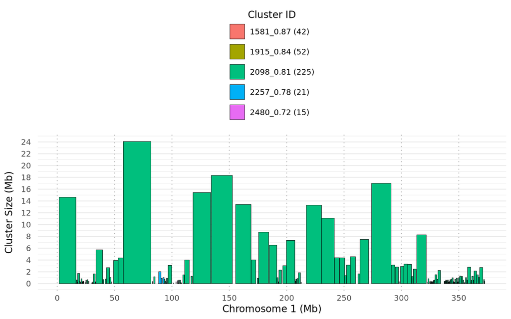

```r
# Merge SNP counts into clusters_data while specifying suffixes
annotated_data <- merge(clusters_data, segment_counts, by = "Cluster")

# Create a new column with Cluster names and SNP counts
annotated_data$Cluster_with_SNPs <- with(annotated_data, paste(Cluster, " (", nSegments, ")", sep=""))

# Now the plot uses the new Cluster_with_SNPs for the fill legend
ggplot(annotated_data, aes(xmin = Start_Mb, xmax = End_Mb, ymin = 0, ymax = Size / 1e6)) +
  geom_rect(aes(fill = as.factor(Cluster_with_SNPs)), color = "black", linewidth = 0.2) +
  scale_x_continuous(labels = scales::label_number(unit = "M"), breaks = scales::pretty_breaks(n = 10)) +
  scale_y_continuous(labels = scales::label_number(unit = "M"), breaks = scales::pretty_breaks(n = 10)) +
  labs(x = "Chromosome 1 (Mb)", y = "Cluster Size (Mb)", fill = "Cluster ID") +
  theme_minimal() +
  theme(
    axis.text.y = element_text(margin = margin(t = 0, r = 5, b = 0, l = 5)),
    axis.ticks.y = element_blank(),
    panel.grid.major.x = element_line(color = "gray", linetype = "dotted"),
    panel.grid.minor.x = element_blank(),
    legend.position = "top",
    legend.box = "horizontal"
  ) +
  guides(fill = guide_legend(nrow = 5, title.position = "top", title.hjust = 0.5))
```

```r
# Use ggsave to save the plot as a PDF
ggsave(
  filename = here("output", "ldna", "pop", "chr1", "clusters", "NEW_chr1.pdf"),
  device = "pdf",
  width = 8,
  height = 5,
  units = "in"
)
```

We can save the data to plot all chromosomes together using a facet plot

```r
head(annotated_data)
```

```
##     Cluster     Start       End     Size   Start_Mb    End_Mb nSegments
## 1 1581_0.87 297829070 298157121   328051 297.829070 298.15712        42
## 2 1915_0.84  24647057  24840528   193471  24.647057  24.84053        52
## 3 1915_0.84 103394842 103704163   309321 103.394842 103.70416        52
## 4 2098_0.81   1671072  16303506 14632434   1.671072  16.30351       225
## 5 2098_0.81  16308219  16458676   150457  16.308219  16.45868       225
## 6 2098_0.81  16560013  16688706   128693  16.560013  16.68871       225
##   Cluster_with_SNPs
## 1    1581_0.87 (42)
## 2    1915_0.84 (52)
## 3    1915_0.84 (52)
## 4   2098_0.81 (225)
## 5   2098_0.81 (225)
## 6   2098_0.81 (225)
```

Save plotting data, we can arrange the column order first

```r
plot_data <- annotated_data |>
  dplyr::select(
    Cluster, nSegments, Start, End, Size, Start_Mb, End_Mb
  )

# Create a new column with Chromosome
plot_data <- data.frame(Chromosome = rep(1, nrow(plot_data)), plot_data)

# Split the 'Cluster' column at "_", and create the 'r2' column with the second part
plot_data$r2 <- sapply(strsplit(as.character(plot_data$Cluster), "_"), `[`, 2)

# Move the 'r2' column to be the second column, right after 'Chromosome'
plot_data <- plot_data[, c(1:2, ncol(plot_data), 3:(ncol(plot_data)-1))]


# Arrange
plot_data <- plot_data |>
  dplyr::arrange(Start)

# Check it
head(plot_data)
```

```
##   Chromosome   Cluster   r2 nSegments    Start      End     Size  Start_Mb
## 1          1 2098_0.81 0.81       225  1671072 16303506 14632434  1.671072
## 2          1 2098_0.81 0.81       225 16308219 16458676   150457 16.308219
## 3          1 2098_0.81 0.81       225 16560013 16688706   128693 16.560013
## 4          1 2098_0.81 0.81       225 16723593 17338376   614783 16.723593
## 5          1 2098_0.81 0.81       225 17376443 17614762   238319 17.376443
## 6          1 2098_0.81 0.81       225 17763447 19491473  1728026 17.763447
##     End_Mb
## 1 16.30351
## 2 16.45868
## 3 16.68871
## 4 17.33838
## 5 17.61476
## 6 19.49147
```

```r
# Save it
saveRDS(plot_data, file = here("output", "ldna", "pop", "chr1", "NEW_plot.rds"))
```

We can also import the summary file to create a object with SNP counts per segment

```r
# Define the path
input_path <-
  here("output",
       "ldna",
       "pop",
       "chr1",
       "summary_NEW.txt")

# Read the data into R
clusters_snps <- read.table(input_path, header = TRUE, sep = "\t")

# We subset and rename the column 1
clusters_snps <- clusters_snps |>
  dplyr::select(
    Name, nLoci
  ) |>
  dplyr::rename(
    Cluster = Name,
    nSNPs = nLoci
  )

# Merge
cluster_seg_snp <- inner_join(segment_counts, clusters_snps, by = "Cluster")
cluster_seg_snp <- inner_join(clusters_data, cluster_seg_snp, by = "Cluster")

# Split the 'Cluster' column at "_", and create the 'r2' column with the second part
cluster_seg_snp$r2 <- sapply(strsplit(as.character(cluster_seg_snp$Cluster), "_"), `[`, 2)

# Add chromosome number and population name
cluster_seg_snp <- data.frame(Chromosome = rep(1, nrow(cluster_seg_snp)), cluster_seg_snp)
cluster_seg_snp <- data.frame(Population = rep("NEW", nrow(cluster_seg_snp)), cluster_seg_snp)


# Reorder the columns
cluster_seg_snp <- cluster_seg_snp |>
  dplyr::select(
    Chromosome, Cluster, r2, Start, End, nSegments, nSNPs
  ) |>
  dplyr::arrange(
    Chromosome, Start
  )

head(cluster_seg_snp)
```

```
##   Chromosome   Cluster   r2    Start      End nSegments nSNPs
## 1          1 2098_0.81 0.81  1671072 16303506       225  3339
## 2          1 2098_0.81 0.81 16308219 16458676       225  3339
## 3          1 2098_0.81 0.81 16560013 16688706       225  3339
## 4          1 2098_0.81 0.81 16723593 17338376       225  3339
## 5          1 2098_0.81 0.81 17376443 17614762       225  3339
## 6          1 2098_0.81 0.81 17763447 19491473       225  3339
```

```r
# Save the data for plotting later
saveRDS(cluster_seg_snp, file = here("output", "ldna", "pop", "chr1", "NEW_plot2.rds"))
```

### 3.2 AUT

Clean env and memory

```r
# Remove all objects from the environment
rm(list = ls())

# Run the garbage collector to free up memory
gc()
```

```
##           used (Mb) gc trigger   (Mb)  max used   (Mb)
## Ncells 1584233 84.7    2978834  159.1   2281637  121.9
## Vcells 2881257 22.0  263507405 2010.5 411726494 3141.3
```

Import the data

```r
ld1 <-
  read.delim(
    here("output", "ldna", "pop", "chr1", "AUT.chr1.txt"),
    sep = "\t",
    header = T,
    row.names = 1,
    stringsAsFactors = F,
    check.names = FALSE
  )
```

Check the LD matrix we built using bash

```r
head(ld1)
```

[output not shown]

[output cut: 10284 more lines]

[output not shown]

The row and column names are correct. Now we can convert the data frame to matrix

```r
# Create the matrix for ldna
ld2<- as.matrix(sapply(ld1, as.numeric))

# Get names
names<- rownames(ld1)
#names<-gsub("-", ".", names)

# Add names
row.names(ld2)<-names

# Clean non-numeric values
ld2[is.nan(ld2)] <- NA
ld2[is.infinite(ld2)] <- NA

# Remove diagonal values = 1
diag(ld2)=NA

# Make sure it is only the lower triangle matrix
ld2[!lower.tri(ld2)] <- NA
```

Create a LDna object

```r
# create the LDna object (change the number of cores as needed)
diag(ld2) <- NA
ld2[!lower.tri(ld2)] <- NA
ldna <- LDnaRaw(ld2, mc.cores=2, method = "single")
```

Check the object

```r
str(ldna)
```

```
## List of 3
##  $ clusterfile: logi [1:7385, 1:2040] TRUE TRUE TRUE TRUE TRUE TRUE ...
##   ..- attr(*, "dimnames")=List of 2
##   .. ..$ : chr [1:7385] "AX-583033342" "AX-583035163" "AX-583035194" "AX-583035257" ...
##   .. ..$ : chr [1:2040] "2040_0.31" "2039_0.33" "2038_0.35" "770_1" ...
##  $ stats      :Classes 'data.table' and 'data.frame':    9425 obs. of  8 variables:
##   ..$ cluster       : chr [1:9425] "2040_0.31" "2039_0.33" "2038_0.35" "2037_0.38" ...
##   ..$ parent_cluster: chr [1:9425] "root" "2040_0.31" "2039_0.33" "2038_0.35" ...
##   ..$ distance      : chr [1:9425] "0.31" "0.02" "0.02" "0.03" ...
##   ..$ nV            : num [1:9425] 7385 7384 7381 7378 7377 ...
##   ..$ nE            : num [1:9425] 2604035 2455804 2240026 1941527 1755622 ...
##   ..$ min_LD        : num [1:9425] 0 0 0 0 0 0 0 0 0 0 ...
##   ..$ merge_at_below: num [1:9425] 0 0.31 0.33 0.35 0.38 0.4 0.41 0.43 0.44 0.46 ...
##   ..$ merge_at_above: num [1:9425] NA 0.33 0.35 0.38 0.4 0.41 0.43 0.44 0.46 0.47 ...
##   ..- attr(*, ".internal.selfref")=<externalptr>
##   ..- attr(*, "index")= int(0)
##   .. ..- attr(*, "__nE")= int [1:9425] 1441 1621 1917 1963 2031 2041 2042 2043 2044 2045 ...
##   .. ..- attr(*, "__parent_cluster")= int [1:9425] 1768 6387 6388 465 1093 225 5122 592 1208 4636 ...
##   .. ..- attr(*, "__cluster")= int [1:9425] 1229 398 223 480 1081 314 949 923 229 1360 ...
##  $ tree       :List of 4
##   ..$ edge       : int [1:9424, 1:2] 7386 7386 7387 7387 7387 7387 7388 7389 7389 7389 ...
##   ..$ edge.length: num [1:9424] 0.345 0.01 0.335 0.335 0.335 0.01 0.325 0 0 0 ...
##   ..$ tip.label  : chr [1:7385] "AX-583033342" "AX-583035163" "AX-583035194" "AX-583035257" ...
##   ..$ Nnode      : int 2040
##   ..- attr(*, "class")= chr "phylo"
##   ..- attr(*, "order")= chr "cladewise"
```

Save it

```r
saveRDS(ldna, file = here("output", "ldna", "pop", "chr1", "AUT.rds"))
saveRDS(ld2, file = here("output", "ldna", "pop", "chr1", "AUT_ld2.rds"))
```

Import data

```r
ldna <- readRDS(here("output", "ldna", "pop", "chr1", "AUT.rds"))
ld2 <- readRDS(here("output", "ldna", "pop", "chr1", "AUT_ld2.rds"))
```

Extract clusters using min.edges=100

```r
pdf(file = here("output", "ldna", "pop", "chr1", "AUT_extractBranches.pdf"), width = 20, height = 12)
op <- par(mfcol=c(1,4))

clusters <- extractBranches(ldna, min.edges=100, plot.tree=TRUE, cores=1)
summary <- summaryLDna(ldna, clusters, ld2)
write.table(summary, file = here("output", "ldna", "pop", "chr1", "summary_AUT.txt"), row.names=FALSE, sep="\t", quote=FALSE)

par(op)
while (!is.null(dev.list())) dev.off()
```

Get cluster information

```r
# to get the list of names of the clusters
# Find the length of the longest vector
max_length <- max(sapply(clusters, length))

# Function to pad vectors with NAs to make them the same length
pad_vector_to_max_length <- function(vec, max_length) {
  c(vec, rep(NA, max_length - length(vec)))
}

# Apply the padding function to each vector in the list and combine into a data frame
do1 <- as.data.frame(do.call(cbind, lapply(clusters, pad_vector_to_max_length, max_length)))

# to get list of snps for each cluster
do <- do.call(cbind, unname(lapply(clusters, `length<-`, max(lengths(clusters)))))
colnames(do) <- colnames(do1)
```

Save it

```r
max_length <- max(sapply(clusters, length))
# Initialize an empty list
cluster_df_list <- list()

# Loop through each cluster and pad with NAs
for (cluster_name in names(clusters)) {
  cluster_length <- length(clusters[[cluster_name]])
  padded_cluster <- c(clusters[[cluster_name]], rep(NA, max_length - cluster_length))
  cluster_df_list[[cluster_name]] <- padded_cluster
}

# Combine the lists into a data frame
df <- data.frame(cluster_df_list)
# Remove 'X' from column names
names(df) <- make.names(names(df), unique = FALSE)
names(df) <- sub("X", "", names(df), fixed = TRUE)

# Save it
saveRDS(df, file = here("output", "ldna", "pop", "chr1", "AUT_clusters_snps.rds"))
head(df)
```

```
##      1868_0.72    1980_0.63     1908_0.7     2000_0.6    1978_0.63    1971_0.64
## 1 AX-583431682 AX-583058478 AX-583535984 AX-583535944 AX-583656116 AX-583500511
## 2 AX-583433318 AX-583057722 AX-583539059 AX-583533335 AX-583892406 AX-583500520
## 3 AX-583433750 AX-583058629 AX-583539673 AX-583536569 AX-583888304 AX-583503153
## 4 AX-583434608 AX-583060489 AX-583541426 AX-583536002 AX-583892527 AX-583500379
## 5 AX-583437752 AX-583350116 AX-583541650 AX-583537293 AX-583892551 AX-583503258
## 6 AX-583438295 AX-583350843 AX-583539120 AX-583541544 AX-583893585 AX-583504302
##      1352_0.88    1976_0.63    1965_0.64    1946_0.66    1458_0.86    1938_0.67
## 1 AX-583743892 AX-583586175 AX-583229152 AX-583045158 AX-583555178 AX-583539468
## 2 AX-583743894 AX-583743824 AX-583230001 AX-583046117 AX-583557056 AX-583539627
## 3 AX-583743987 AX-583743998 AX-583230062 AX-583052719 AX-583554354 AX-583542359
## 4 AX-583748192 AX-583747965 AX-583233057 AX-583052916 AX-583558145 AX-583542421
## 5 AX-583744447 AX-583748013 AX-583595717 AX-583054862 AX-583557195 AX-583542929
## 6 AX-583748419 AX-583748046 AX-583604842 AX-583056500 AX-583561812 AX-583542972
##      1927_0.68    1934_0.67     1706_0.8    1877_0.71    1289_0.89    1814_0.75
```

[output cut: 34 more lines]

We can save it in a different format as well

```r
# Assuming your data frame is named df
long_df <- gather(df, Cluster, SNP, everything())

# View the first few rows of the transformed data
head(long_df)
```

```
##     Cluster          SNP
## 1 1868_0.72 AX-583431682
## 2 1868_0.72 AX-583433318
## 3 1868_0.72 AX-583433750
## 4 1868_0.72 AX-583434608
## 5 1868_0.72 AX-583437752
## 6 1868_0.72 AX-583438295
```

```r
# Save it
saveRDS(long_df, file = here("output", "ldna", "pop", "chr1", "AUT_clusters_snps1.rds"))
```

Make long format

```r
aut_chr1 <- melt(do, na.rm = T, value.name = "value")
head(aut_chr1)
```

```
##   Var1      Var2        value
## 1    1 1868_0.72 AX-583431682
## 2    2 1868_0.72 AX-583433318
## 3    3 1868_0.72 AX-583433750
## 4    4 1868_0.72 AX-583434608
## 5    5 1868_0.72 AX-583437752
## 6    6 1868_0.72 AX-583438295
```

Update names

```r
colnames(aut_chr1)<- c("v1", "cluster", "SNP")
head(aut_chr1)
```

```
##   v1   cluster          SNP
## 1  1 1868_0.72 AX-583431682
## 2  2 1868_0.72 AX-583433318
## 3  3 1868_0.72 AX-583433750
## 4  4 1868_0.72 AX-583434608
## 5  5 1868_0.72 AX-583437752
## 6  6 1868_0.72 AX-583438295
```

Import the bim file to get the SNP positions

```r
# Import the function
source(
  here(
    "notebooks", "helpers", "import_bim.R")
)

# Import the data
aut_snps_chr1 <- import_bim(here("output", "ldna", "pop", "AUT.bim")) |>
  dplyr::select(
    SNP, Scaffold, Position
  ) |>
  dplyr::rename(
    Chromosome = Scaffold
  )

# Check it
head(aut_snps_chr1)
```

```
## # A tibble: 6 x 3
##   SNP          Chromosome Position
##   <chr>        <chr>         <dbl>
## 1 AX-583033342 1            315059
## 2 AX-583035163 1            315386
## 3 AX-583035194 1            330265
## 4 AX-583035257 1            442875
## 5 AX-583035355 1            540754
## 6 AX-583034838 1           1138155
```

Merge the cluster data and the SNP data

```r
# merge dataframes
merged<- merge(aut_chr1, aut_snps_chr1, by="SNP", all.x=TRUE)
merged<-na.omit(merged)
head(merged)
```

```
##            SNP v1   cluster Chromosome Position
## 1 AX-583035342  2 1927_0.68          1  1278179
## 2 AX-583035538  1 1934_0.67          1  1283423
## 3 AX-583036374  2 1934_0.67          1  1353955
## 4 AX-583036705  3 1927_0.68          1  1380337
## 5 AX-583036983  1 1927_0.68          1  1276832
## 6 AX-583037932  3 1934_0.67          1  1515590
```

Select the columns we need

```r
# subset
merged <- subset(merged, select = c(cluster, SNP, Position))
head(merged)
```

```
##     cluster          SNP Position
## 1 1927_0.68 AX-583035342  1278179
## 2 1934_0.67 AX-583035538  1283423
## 3 1934_0.67 AX-583036374  1353955
## 4 1927_0.68 AX-583036705  1380337
## 5 1927_0.68 AX-583036983  1276832
## 6 1934_0.67 AX-583037932  1515590
```

Sort by distance

```r
merged<- merged[order(merged$Position),,drop=FALSE]
head(merged)
```

```
##     cluster          SNP Position
## 5 1927_0.68 AX-583036983  1276832
## 1 1927_0.68 AX-583035342  1278179
## 2 1934_0.67 AX-583035538  1283423
## 3 1934_0.67 AX-583036374  1353955
## 4 1927_0.68 AX-583036705  1380337
## 6 1934_0.67 AX-583037932  1515590
```

```r
# for parsing later
sushi1<- subset(merged, select = c(cluster, Position))
head(sushi1)
```

```
##     cluster Position
## 5 1927_0.68  1276832
## 1 1927_0.68  1278179
## 2 1934_0.67  1283423
## 3 1934_0.67  1353955
## 4 1927_0.68  1380337
## 6 1934_0.67  1515590
```

Save the data

```r
# Create directory
new_directory_path <- here("output", "ldna", "pop", "chr1", "clusters")
dir.create(new_directory_path, recursive = TRUE)

# save file
write.table(merged, file = here("output", "ldna", "pop", "chr1", "SNPs_clusters_AUT_chr1.txt"), row.names = F, sep = "\t", quote = F)
write.table(sushi1, file = here("output", "ldna", "pop", "chr1", "clusters", "sushi_AUT_chr1.txt"), row.names = F, sep = "\t", quote = F)
```

Parse the file1 to get the start and end of the clusters as well as their size. Remember, recombination make it a mosaic, so the clusters are “mixed”.

```bash
awk '
function print_row() {
    if ( feature != "" )
       print feature, start, end, (end - start)
}

BEGIN {
    FS=OFS="\t";
    print "Cluster", "Start", "End", "Size";
}
NR == 1 { next } # Skip the first line
$1 != feature {
    print_row();
    feature = $1;
    start = $2;
    end = $2;
    next;
}
{
    end = $2;
}
END {
    print_row();
}
' output/ldna/pop/chr1/clusters/sushi_AUT_chr1.txt > output/ldna/pop/chr1/clusters/sushi2_AUT_chr1.txt;
head output/ldna/pop/chr1/clusters/sushi2_AUT_chr1.txt
```

```
## Cluster  Start   End Size
## 1927_0.68    1276832 1278179 1347
## 1934_0.67    1283423 1353955 70532
## 1927_0.68    1380337 1380337 0
## 1934_0.67    1515590 1515590 0
## 1927_0.68    1556931 1556931 0
## 1934_0.67    1592763 1592763 0
## 1927_0.68    1619834 2269308 649474
## 1934_0.67    2339987 2339987 0
## 1877_0.71    2371768 2371768 0
```

```r
# Define the path
input_path <- here("output", "ldna", "pop", "chr1", "clusters", "sushi2_AUT_chr1.txt")

# Read the data into R
clusters_data <- read_table(input_path, col_names = TRUE, col_types = NULL)
# Arrange by position
clusters_data <- clusters_data |>
  arrange(Start)

# Count segments for each cluster - if you want only the counts
segment_counts <- clusters_data %>%
  group_by(Cluster) %>%
  summarize(nSegments = n(), .groups = 'drop')

# View the result
head(segment_counts)
```

```
## # A tibble: 6 x 2
##   Cluster   nSegments
##   <chr>         <int>
## 1 1284_0.89        22
## 2 1289_0.89        20
## 3 1352_0.88         4
## 4 1458_0.86        12
## 5 1545_0.84        20
## 6 1559_0.84        33
```

Plot it

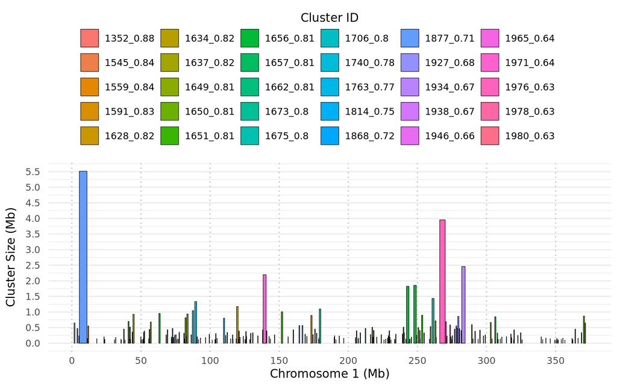

```r
# Define the path
input_path <-
  here("output",
       "ldna",
       "pop",
       "chr1",
       "clusters",
       "sushi2_AUT_chr1.txt")

# Read the data into R
clusters_data <- read.table(input_path, header = TRUE, sep = "\t") |>
  arrange(Start)

# Arrange by position
clusters_data <- clusters_data |>
  arrange(Start)

# Filter out rows with Size equal to 0
clusters_data <- subset(clusters_data, Size > 100000) # show only bigger than 100kb


# Calculate the maximum size for scaling
max_size <- max(clusters_data$Size)

# Create Start_Mb and End_Mb within clusters_data
clusters_data$Start_Mb <- clusters_data$Start / 1e6
clusters_data$End_Mb <- clusters_data$End / 1e6

# Create the plot
ggplot(clusters_data, aes(xmin = Start_Mb, xmax = End_Mb, ymin = 0, ymax = Size / 1e6)) +
  geom_rect(aes(fill = as.factor(Cluster)), color = "black", linewidth = 0.2) +
  scale_x_continuous(labels = label_number(unit = "M"), breaks = pretty_breaks(n = 10)) +
  scale_y_continuous(labels = label_number(unit = "M"), breaks = pretty_breaks(n = 10)) +
  labs(x = "Chromosome 1 (Mb)", y = "Cluster Size (Mb)", fill = "Cluster ID") +
  theme_minimal() +
  theme(
    axis.text.y = element_text(margin = margin(t = 0, r = 5, b = 0, l = 5)),
    axis.ticks.y = element_blank(),
    panel.grid.major.x = element_line(color = "gray", linetype = "dotted"),
    panel.grid.minor.x = element_blank(),
    legend.position = "top",
    legend.box = "horizontal"
  ) +
  guides(fill = guide_legend(ncol = 7, title.position = "top", title.hjust = 0.5))
```

```r
# Use ggsave to save the plot as a PDF
# ggsave(
#   filename = here("output", "ldna", "pop", "chr1", "clusters", "AUT_chr1.pdf"),
#   device = "pdf",
#   width = 8,
#   height = 5,
#   units = "in"
# )
```

We can annotate the number of segments in the legend.

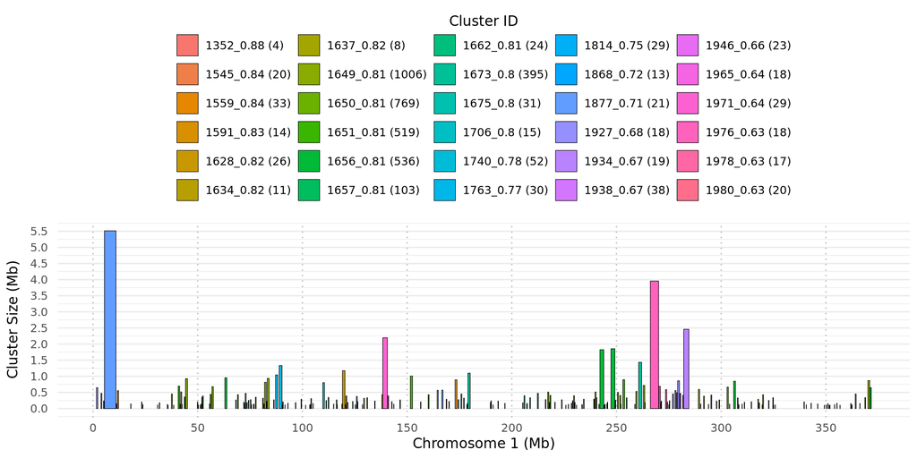

```r
# Merge SNP counts into clusters_data while specifying suffixes
annotated_data <- merge(clusters_data, segment_counts, by = "Cluster")

# Create a new column with Cluster names and SNP counts
annotated_data$Cluster_with_SNPs <- with(annotated_data, paste(Cluster, " (", nSegments, ")", sep=""))

# Now the plot uses the new Cluster_with_SNPs for the fill legend
ggplot(annotated_data, aes(xmin = Start_Mb, xmax = End_Mb, ymin = 0, ymax = Size / 1e6)) +
  geom_rect(aes(fill = as.factor(Cluster_with_SNPs)), color = "black", linewidth = 0.2) +
  scale_x_continuous(labels = scales::label_number(unit = "M"), breaks = scales::pretty_breaks(n = 10)) +
  scale_y_continuous(labels = scales::label_number(unit = "M"), breaks = scales::pretty_breaks(n = 10)) +
  labs(x = "Chromosome 1 (Mb)", y = "Cluster Size (Mb)", fill = "Cluster ID") +
  theme_minimal() +
  theme(
    axis.text.y = element_text(margin = margin(t = 0, r = 5, b = 0, l = 5)),
    axis.ticks.y = element_blank(),
    panel.grid.major.x = element_line(color = "gray", linetype = "dotted"),
    panel.grid.minor.x = element_blank(),
    legend.position = "top",
    legend.box = "horizontal"
  ) +
  guides(fill = guide_legend(nrow = 6, title.position = "top", title.hjust = 0.5))
```

```r
# Use ggsave to save the plot as a PDF
ggsave(
  filename = here("output", "ldna", "pop", "chr1", "clusters", "AUT_chr1.pdf"),
  device = "pdf",
  width = 10,
  height = 5,
  units = "in"
)
```

Save plotting data, we can arrange the column order first

```r
plot_data <- annotated_data |>
  dplyr::select(
    Cluster, nSegments, Start, End, Size, Start_Mb, End_Mb
  )

# Create a new column with Chromosome
plot_data <- data.frame(Chromosome = rep(1, nrow(plot_data)), plot_data)

# Split the 'Cluster' column at "_", and create the 'r2' column with the second part
plot_data$r2 <- sapply(strsplit(as.character(plot_data$Cluster), "_"), `[`, 2)

# Move the 'r2' column to be the second column, right after 'Chromosome'
plot_data <- plot_data[, c(1:2, ncol(plot_data), 3:(ncol(plot_data)-1))]


# Arrange
plot_data <- plot_data |>
  dplyr::arrange(Start)

# Check it
head(plot_data)
```

```
##   Chromosome   Cluster   r2 nSegments    Start      End    Size  Start_Mb
## 1          1 1927_0.68 0.68        18  1619834  2269308  649474  1.619834
## 2          1 1877_0.71 0.71        21  3766945  4238554  471609  3.766945
## 3          1 1946_0.66 0.66        23  4981859  5217622  235763  4.981859
## 4          1 1877_0.71 0.71        21  5443736 10957198 5513462  5.443736
## 5          1 1980_0.63 0.63        20 11125830 11276238  150408 11.125830
## 6          1 1559_0.84 0.84        33 11638599 12192074  553475 11.638599
##      End_Mb
## 1  2.269308
## 2  4.238554
## 3  5.217622
## 4 10.957198
## 5 11.276238
## 6 12.192074
```

```r
# Save it
saveRDS(plot_data, file = here("output", "ldna", "pop", "chr1", "AUT_plot.rds"))
```

We can also import the summary file to create a object with SNP counts per segment

```r
# Define the path
input_path <-
  here("output",
       "ldna",
       "pop",
       "chr1",
       "summary_AUT.txt")

# Read the data into R
clusters_snps <- read.table(input_path, header = TRUE, sep = "\t")

# We subset and rename the column 1
clusters_snps <- clusters_snps |>
  dplyr::select(
    Name, nLoci
  ) |>
  dplyr::rename(
    Cluster = Name,
    nSNPs = nLoci
  )

# Merge
cluster_seg_snp <- inner_join(segment_counts, clusters_snps, by = "Cluster")
cluster_seg_snp <- inner_join(clusters_data, cluster_seg_snp, by = "Cluster")

# Split the 'Cluster' column at "_", and create the 'r2' column with the second part
cluster_seg_snp$r2 <- sapply(strsplit(as.character(cluster_seg_snp$Cluster), "_"), `[`, 2)

# Add chromosome number and population name
cluster_seg_snp <- data.frame(Chromosome = rep(1, nrow(cluster_seg_snp)), cluster_seg_snp)
cluster_seg_snp <- data.frame(Population = rep("AUT", nrow(cluster_seg_snp)), cluster_seg_snp)


# Reorder the columns
cluster_seg_snp <- cluster_seg_snp |>
  dplyr::select(
    Chromosome, Cluster, r2, Start, End, nSegments, nSNPs
  ) |>
  dplyr::arrange(
    Chromosome, Start
  )

head(cluster_seg_snp)
```

```
##   Chromosome   Cluster   r2    Start      End nSegments nSNPs
## 1          1 1927_0.68 0.68  1619834  2269308        18    43
## 2          1 1877_0.71 0.71  3766945  4238554        21    46
## 3          1 1946_0.66 0.66  4981859  5217622        23    30
## 4          1 1877_0.71 0.71  5443736 10957198        21    46
## 5          1 1980_0.63 0.63 11125830 11276238        20    31
## 6          1 1559_0.84 0.84 11638599 12192074        33    42
```

```r
# Save the data for plotting later
saveRDS(cluster_seg_snp, file = here("output", "ldna", "pop", "chr1", "AUT_plot2.rds"))
```